# Analysing language models’ behavior on Federmeier and Kutas (1999)

A demo for the HSP online speaker series, organized by Yuhan Zhang!

Kanishka Misra https://kanishka.website (Toyota Technological Institute at Chicago)https://ttic.edu  
2025-04-11

**Note:** If you run this on RStudio, please change your Rmarkdown settings to evaluate chunks in the Project and not the Directory of this file. Without that, the chunks that involve reading of files will not work.

## Importing libraries

```r
library(tidyverse)
library(scales)
library(fs)
library(reactable)
```

## Model meta data

Useful for plotting and grouping by model families!

```r
models <- c("opt-125m", "opt-350m", "opt-1.3b", "opt-2.7b", "opt-6.7b",
            "pythia-70m", "pythia-160m", "pythia-410m", "pythia-1b", "pythia-1.4b",
            "pythia-2.8b", "pythia-6.9b", "pythia-12b",
            "rwkv4-169m", "rwkv4-430m", "rwkv4-1b", "rwkv4-3b", "rwkv4-7b",
            "mamba-130m", "mamba-370m", "mamba-790m", "mamba-1.4b", "mamba-2.8b")
model_family <- c(rep("OPT", 5), rep("Pythia", 8), rep("RWKV", 5), rep("Mamba", 5))

model_meta <- tibble(
  model = factor(models, levels = models),
  family = factor(model_family, levels = c("OPT", "Pythia", "RWKV", "Mamba"))
)
```

## The stimuli

```r
# Federmeier and Kutas' stimuli
fk_stimuli <- read_csv("data/fk1999-final.csv")
```

The Federmeier and Kutas (1999) dataset consists of the following columns:

- **item:** item id (total 132)
- **prefix:** the two-sentence stimulus shown to participants, the second sentence is incomplete, in the sense that it is missing the last word.
- **expected:** word that is the best completion (i.e., most expected) to the prefix.
- **within:** word that is not a highly expected completion but belongs to the same taxonomic category as **expected**, i.e., it is a *within*-category violation.
- **between:** word that is not a highly expected completion but belongs to a relatively *different* taxonomic category as **expected**, i.e., shares far fewer features with it than does the **within** word.
- **cloze_expected:** the cloze probability for the expected continuation, which is measured to determine the amount of contextual constraint placed by the prefix stimulus.
- **constraint:** high or low, based on a median split on **cloze_expected**

P.S.: I’ve hidden the code I used to show this table, please check out the source code if you are interested.

| item | prefix | expected | within | between | cloze (expected) | constraint |
| --- | --- | --- | --- | --- | --- | --- |
| 1 | Ann wanted to treat her foreign guests to an all-American pie. She went out in the back yard and picked some | apples | oranges | carrots | 0.818 | high |
| 2 | Every morning, Jack makes himself a glass of fresh-squeezed juice. He keeps his refrigerator stocked with | oranges | apples | tomatoes | 0.678 | low |
| 3 | Sheila loves the taste of home-made spaghetti sauce. She decided to start growing her own | tomatoes | carrots | apples | 0.782 | low |
| 4 | They told the little boy it was Bugs Bunny's favorite food. But he still didn't want to eat his | carrots | tomatoes | oranges | 0.932 | high |
| 5 | Robert saw the hive and immediately froze. He was extremely afraid of | bees | spiders | rats | 0.857 | high |
| 6 | There were several webs built across the path. However, Sally didn't actually see any | spiders | bees | rabbits | 0.818 | high |
| 7 | With a flourish, the magician reached into his hat. To the delight of the children he pulled out, not one, but two | rabbits | rats | spiders | 0.857 | high |
| 8 | John liked his job in the psychology lab, but he worried about getting bitten. He didn't really feel comfortable working with the | rats | rabbits | bees | 0.436 | low |
| 9 | The gardener really impressed his wife on Valentine's Day. To surprise her, he had secretly grown some | roses | tulips | palms | 0.786 | high |
| 10 | The tourist in Holland stared in awe at the rows and rows of color. She wished she lived in a country where they grew | tulips | roses | pines | 0.17 | low |

[output cut: 122 more lines]

## Loading in model results

Had do a bit of pre-processing to make sure LM names look pretty…

```r
results <- dir_ls("results/fk1999/", regexp = "*.csv") %>%
  map_df(read_csv, .id = "model") %>%
  mutate(
    model = str_extract(model, "(?<=results/fk1999/)(.*)(?=\\.csv)"),
    model = str_remove(model, "facebook__|EleutherAI__|RWKV__|state-spaces__"),
    model = str_remove(model, "-deduped|-pile|-hf"),
    model = str_replace(model, "-4-", "4-"),
    model = str_replace(model, "1b5", "1b"),
    model = factor(model, levels = models)
  ) %>%
  inner_join(fk_stimuli %>% select(item, cloze_expected, constraint))

model_meta <- model_meta %>%
  inner_join(results %>% distinct(model, parameters))
```

### How often do the tested LMs show compatibility with the findings of F&K (1999)?

Federmeier and Kutas (1999) found the N400 patterns to show some sensitivity to the completions which were not expected, but shared a semantic category with the actual expected completion. In their findings, the **expected** continuation did not elicit an N400 effect, while the **between** continuation did, in line with what was known about the N400. At the same time, while the **within** category violation—which shared many semantic features with the expected word—also elicited an N400 in participants, its amplitude was systematically moderate compared that of **between**. This suggested that the N400 might be sensitive to the structure of long-term semantic memory.

Insofar as the surprisal tracks similar information as the N400, we should see the following pattern emerge:

$$\texttt{surprisal}(expected) < \texttt{surprisal}(within) < \texttt{surprisal}(between)$$

### How often is this pattern observed?

To answer this question, we will measure the percentage of time the above condition holds across all our models. Below I show a plot with these results, with the x axis indicating the total number of parameters, and the y axis indicating the percentage of time the pattern holds.

Since the condition involves 2 comparisons that must simultaneously be true, chance performance is equivalent to two coin flips – i.e., $0.5^2$ or $0.25$. This will be indicated with a *dashed* line in the plot.

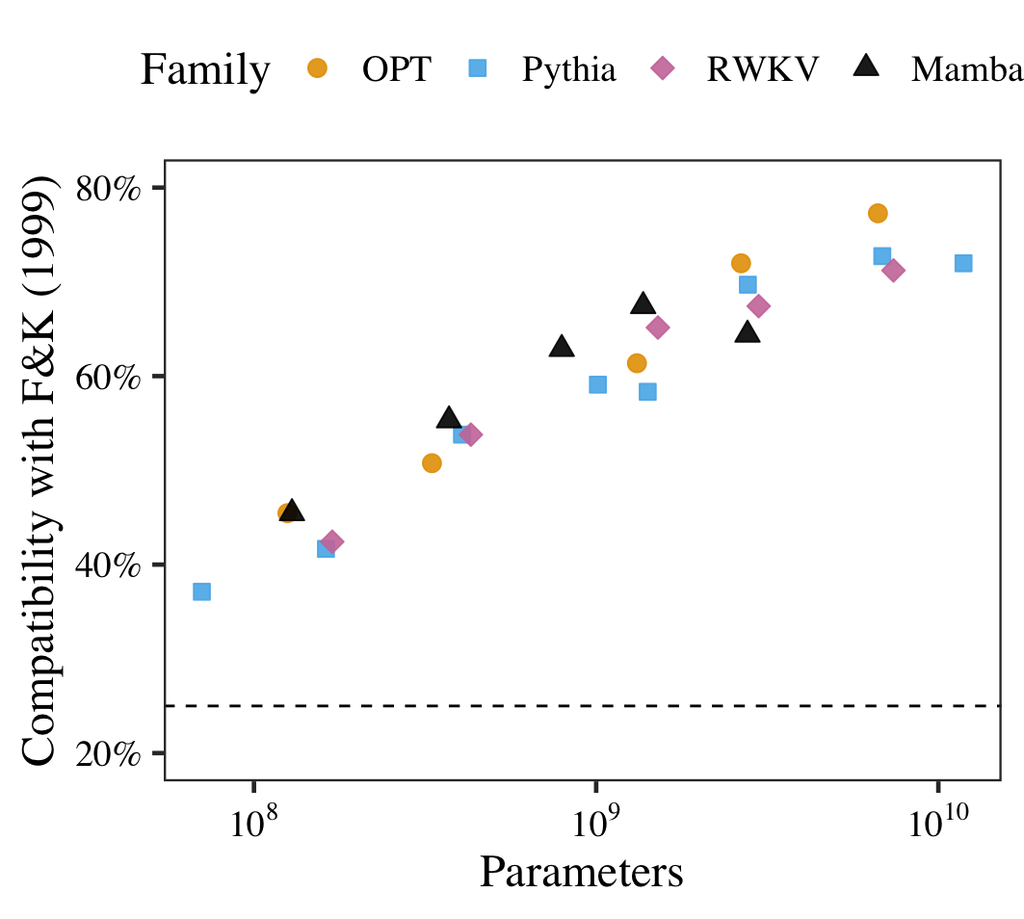

We can also look at it from the perspective of average surprisal values across completion types, across models

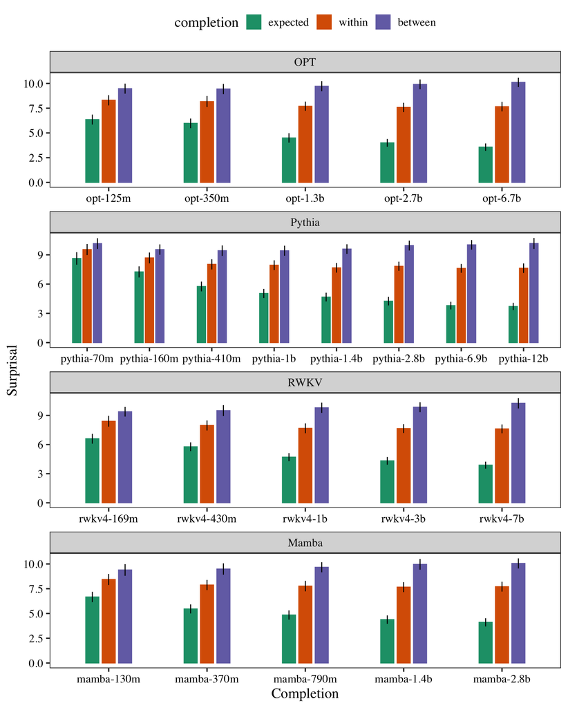

### Does surprisal show analogous sensitivity to constraint as the N400?

Federmeier and Kutas (1999) found the N400 amplitude of the within-category violation to be greater for low-constraint contexts than for high-constraint contexts; while those for expected and between-category violations were not found to be significantly different. Insofar as LM surprisals qualitatively mimic N400 patterns, we should find similar trends. That is, the surprisal of the within category violations in the low constraint contexts should be greater than that in high constraint contexts, while no effect should be found for surprisals for expected and betwee-category violations.

While this should ideally be resolved by doing a linear mixed effects model comparison, with random effects for item (prefix) and model and an interaction term involving constraint (high vs. low) and completion (expected, within, between), we will just look at it via plots:

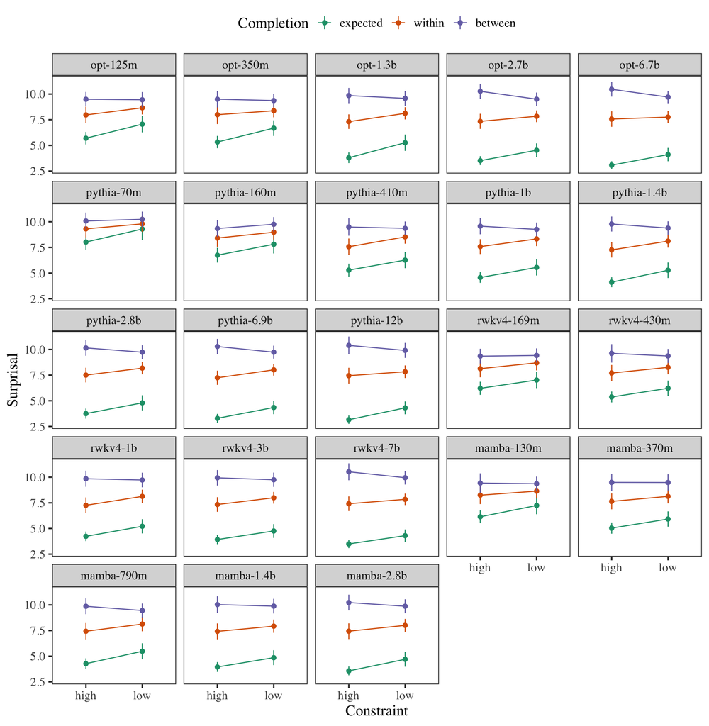

Even if there end up being globally significant differences between within category violations for high and low constraint contexts, the visual analysis suggests that expected and between-category violations also seem to show significant effects of constraint, contrary to the no-effect finding in Federmeier and Kutas (1999).

If true (have to run `lmer` models to find out), then this would suggest that the patterning of LM surprisal with the N400 wrt contextual constraints is relatively weak. **And so perhaps unsurprisingly, surprisal alone might not be enough to account for the precise/nuanced effect of semantic organization on sentence processing.** You could potentially include a separate variable that computes the taxonomically-sensitive conceptual similarity between the expected and the unexpected items to account for this effect, if you are doing computational modeling.

Distill is a publication format for scientific and technical writing, native to the web.

Learn more about using Distill for R Markdown at https://rstudio.github.io/distill.